# Tema 2.2. Manipulación de datos

#### 2.1.5.1 📝 Ejercicio: slice(), filter(), arrange()

—————————————————————————————————

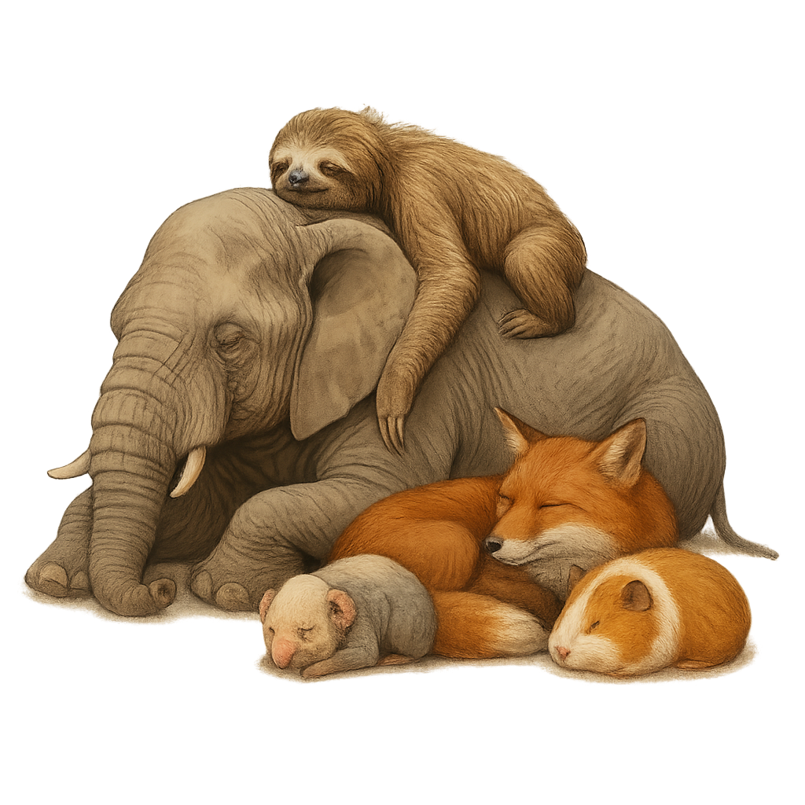

- Lee el data.frame “msleep.csv”. Pista: el delimitador entre datos es la coma (“,”).
- Crea un subset que NO contenga los animales domésticos (campo conservation). ¿Cuantas son?
- Crea un subset de datos que contenga las filas de la 1 a la 5 y de la 18 a la 20, sobre esos datos obten los animales carnívoros. Ordena según las horas de sueño ¿Qué animal duerme más horas?